# Midterm-Inclass

Question 7 (20 points). Consider again the women’s tennis data set, wta_matches_2019.csv, where each row corresponds to a match played on the WTA (Women’s Tennis Association) tour.  
Construct a lollipop chart that shows the 10 WTA tennis players with the highest average number of aces in the 2019 season who have played at least 20 matches.

```r
library(tidyverse)
library(here)
wta_df <- read_csv(here("data/wta_matches_2019.csv"))
```

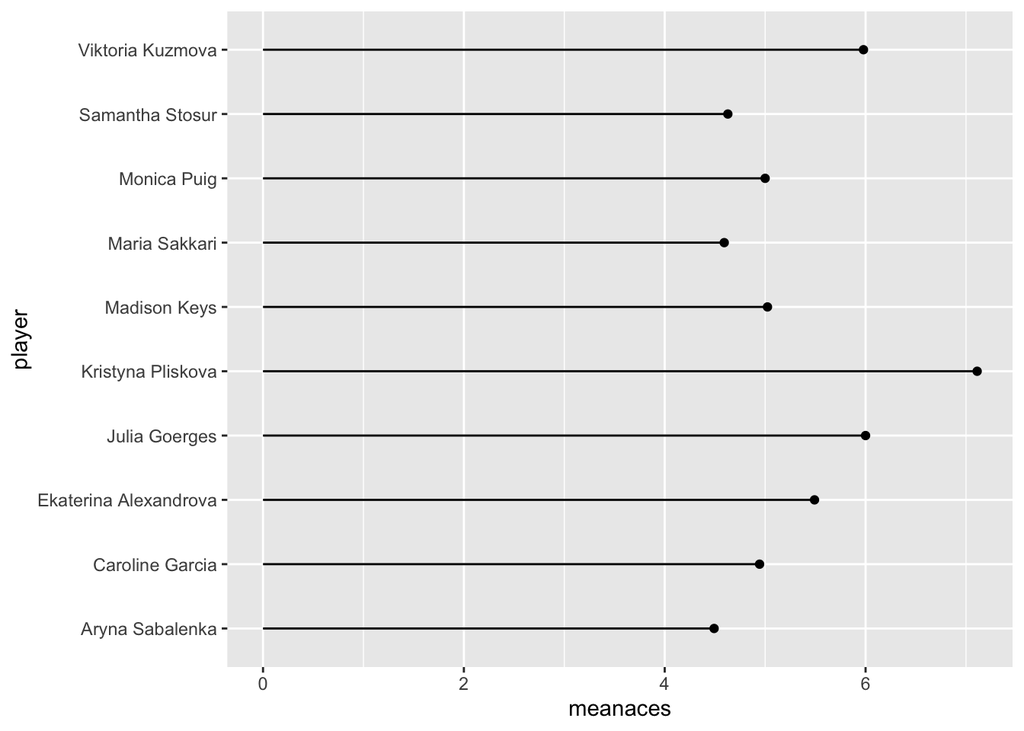

```r
wta_long <- wta_df %>% pivot_longer(c(winner_name, loser_name),
                                    names_to = "won_or_lost",
                                    values_to = "player") %>%
  select(won_or_lost, player, everything())
wta_new <- wta_long %>% mutate(aces = case_when(won_or_lost == "winner_name" ~ "w_ace",
                                     won_or_lost == "loser_name" ~ "l_ace"))
wta_mean <- wta_new %>%
  group_by(player) %>%
  summarise(meanaces = mean(w_ace),
            na.rm = TRUE)

wta_twenty <- wta_new %>%
  group_by(player) %>%
  summarise(nmatches = n()) %>%
  filter(nmatches >= 20)

wta_full <- semi_join(wta_mean, wta_twenty, by = c("player" = "player"))

wta_ten <- wta_full %>% arrange(desc(meanaces)) %>% slice(1:10)


ggplot(data = wta_ten, aes(x = player, y = meanaces)) +
  geom_point() +
  geom_segment(aes(x = player, xend = player, y = 0, yend = meanaces)) +
  coord_flip()
```

Question 8 (20 points).

part a. Consider the lollipop plot you made in Question 7. Why is this plot not the best plot to make to look at the top women’s servers in 2019? (There might be a couple of reasons but you should reference one that we have explicitly talked about in class a lot).  
This plot is not the best plot to make to look at this because it shows a complete line that covers many different values for each server, even though we are only trying to represent the mean aces for each of the players. Mean aces is an average and stands for a single point in a data set, so we shouldn’t use plots that cover a range for each categorical variable. We would want to use these type of plots when we are talking about an area or a count for example. When we are only worried about single data points, then we should just use point plots.  
part b.

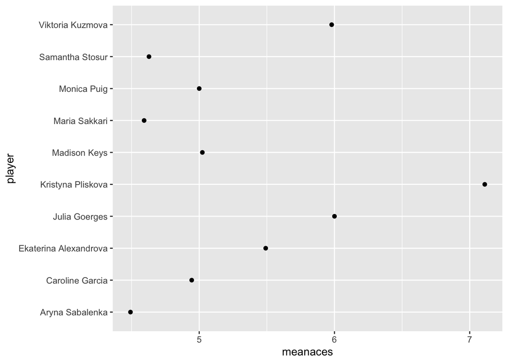

```r
ggplot(data = wta_ten, aes(x = player, y = meanaces)) +
  geom_point() +
  coord_flip()
```